# DV_RProject2

Natasha Halfin, Evan Johnston, Kaylyn Zvonek

For this project, we used a dataset containing information on the top 5000 companies in the country, including their state, city, industry, revenue, and percentage of growth.

This is a dataframe of our entire dataset.

```
##   RANK                        COMPANY
## 1  173 GeBBS Healthcare Solutions (ht
## 2  174 PriceSpective (http://www.inc.
## 3  175 GlobalTranz (http://www.inc.co
## 4  176 MicroTech (http://www.inc.com/
## 5  177 Senior Whole Health (http://ww
## 6  178 AtTask (http://www.inc.com/inc
##                                                                                   COMPANYWEBSITE
## 1 GeBBS Healthcare Solutions (http://www.inc.com/inc5000/2009/company-profile.html?id=200901730)
## 2              PriceSpective (http://www.inc.com/inc5000/2009/company-profile.html?id=200901740)
## 3                GlobalTranz (http://www.inc.com/inc5000/2009/company-profile.html?id=200901750)
## 4                  MicroTech (http://www.inc.com/inc5000/2009/company-profile.html?id=200901760)
## 5        Senior Whole Health (http://www.inc.com/inc5000/2009/company-profile.html?id=200901770)
## 6                     AtTask (http://www.inc.com/inc5000/2009/company-profile.html?id=200901780)
##               CITY STATE                   INDUSTRY   REVENUE GROWTH
## 1 Englewood Cliffs    NJ                     Health   5400000 11.100
## 2        Blue Bell    PA                     Health   9500000 11.098
## 3          Phoenix    AZ Logistics & Transportation  25400000 11.048
## 4           Vienna    VA        Government Services  39000000 11.029
## 5        Cambridge    MA                  Insurance 207700000 10.999
## 6             Orem    UT                   Software  15500000 10.971
##   PERCENTAGEGROWTH
## 1           1110.0
## 2           1109.8
## 3           1104.8
## 4           1102.9
## 5           1099.9
## 6           1097.1
```

This is a dataframe of a subset of our data displaying companies in Texas that are in the IT services industry.

```
##     RANK                        COMPANY
## 163  120 Improving Enterprises (http://
## 170  127 Headspring Systems (http://www
## 353  353 Mystikal Solutions (http://www
## 439  440 American Unit (http://www.inc.
## 444  445 Wise Men Consultants (http://w
## 450  451 Xenosoft Technologies (http://
##                                                                                COMPANYWEBSITE
## 163 Improving Enterprises (http://www.inc.com/inc5000/2009/company-profile.html?id=200901200)
## 170    Headspring Systems (http://www.inc.com/inc5000/2009/company-profile.html?id=200901270)
## 353    Mystikal Solutions (http://www.inc.com/inc5000/2009/company-profile.html?id=200903530)
## 439         American Unit (http://www.inc.com/inc5000/2009/company-profile.html?id=200904400)
## 444  Wise Men Consultants (http://www.inc.com/inc5000/2009/company-profile.html?id=200904450)
## 450 Xenosoft Technologies (http://www.inc.com/inc5000/2009/company-profile.html?id=200904510)
##            CITY STATE    INDUSTRY  REVENUE GROWTH PERCENTAGEGROWTH
## 163      Dallas    TX IT Services  6200000 14.171           1417.1
## 170      Austin    TX IT Services  3500000 13.663           1366.3
## 353 San Antonio    TX IT Services  3900000  6.985            698.5
## 439      Frisco    TX IT Services 32800000  5.849            584.9
## 444     Houston    TX IT Services 20600000  5.809            580.9
## 450      Dallas    TX IT Services 13800000  5.762            576.2
```

This is a dataframe of wrangled data that indicates the average revenue and growth across each industry.

```
##                       INDUSTRY    revMean  groMean
## 1      Advertising & Marketing  873109823 357.2113
## 2 Business Products & Services   37500600 232.3464
## 3            Computer Hardware   88256667 163.1550
## 4                 Construction   53107910 190.5124
## 5 Consumer Products & Services   45950679 401.7045
## 6                    Education 5821433946 224.3738
```

This is a wrangled dataframe displaying companies in Texas and California and their industries.

```
##   RANK STATE                        COMPANY                     INDUSTRY
## 1  180    CA GuardianEdge (http://www.inc.c                     Security
## 2  183    CA The Chip (http://www.inc.com/i                  IT Services
## 3  185    CA Walz Group (http://www.inc.com Business Products & Services
## 4  187    CA cPrime (http://www.inc.com/inc                  IT Services
## 5  188    CA Torrey Hills Technologies (htt                Manufacturing
## 6  194    CA Ignify (http://www.inc.com/inc                  IT Services
```

This wrangled dataframe shows the highest revenue and growth by state.

```
##   STATE  groMax      revMax
## 1    AK   337.1 1.60000e+07
## 2    AL   866.1 9.12000e+08
## 3    AR   404.5 2.32000e+07
## 4    AZ  1396.0 4.97900e+08
## 5    CA 13416.4 3.40549e+11
## 6    CO  2358.4 5.60000e+09
```

This wrangled dataframe indicates the lowest revenue and growth by city.

```
##                  CITY  groMin   revMin
## 1 San Juan Capistrano 13416.4 47400000
## 2         Mill Valley 12749.3 63500000
## 3       Crystal Beach  5970.8 19400000
## 4          Chanhassen  5906.8 31700000
## 5          Plaisnboro  5884.9 15000000
## 6            Yorktown  5778.9 12000000
```

Data Visualizations

**Industry Revenues** This plot shows the average revenue for each industry. Because the revenues are so varied, they are split up into 6 groups of similar revenue values.

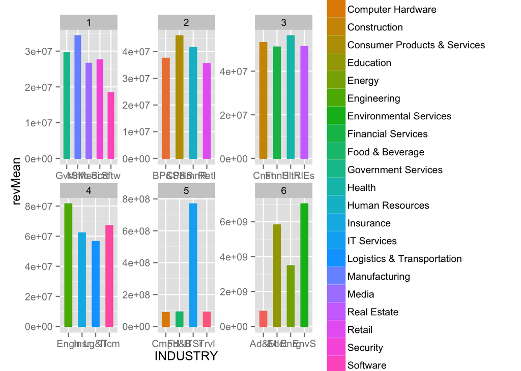

**Industry Growth** This plot shows the average growth for each industry, ordered from least growth to most

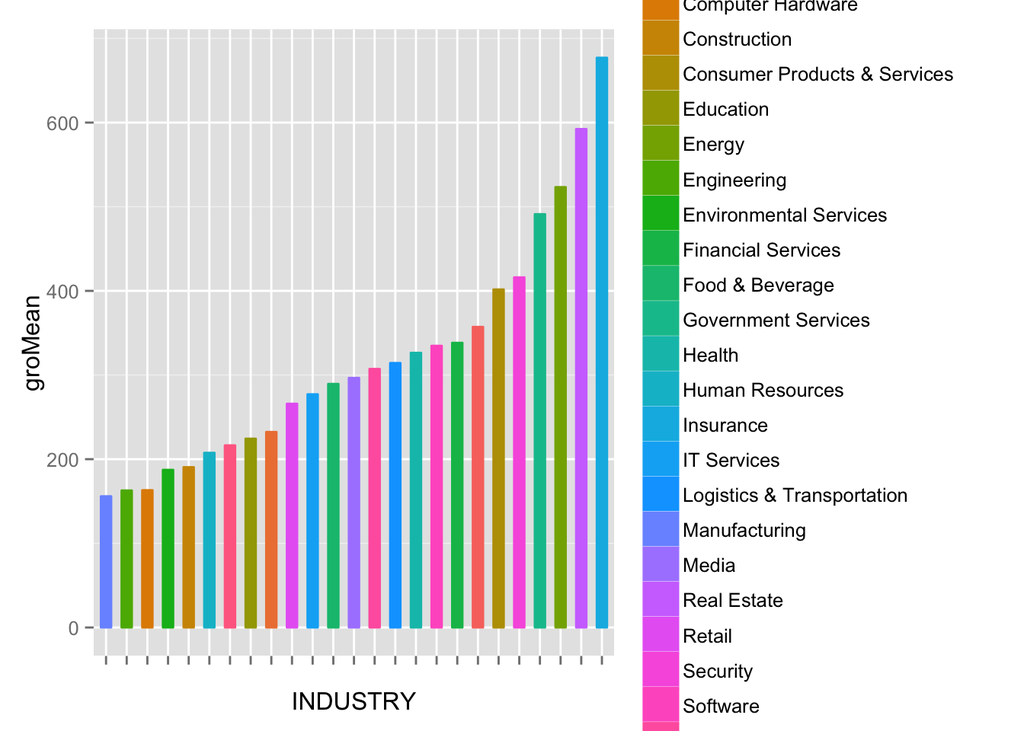

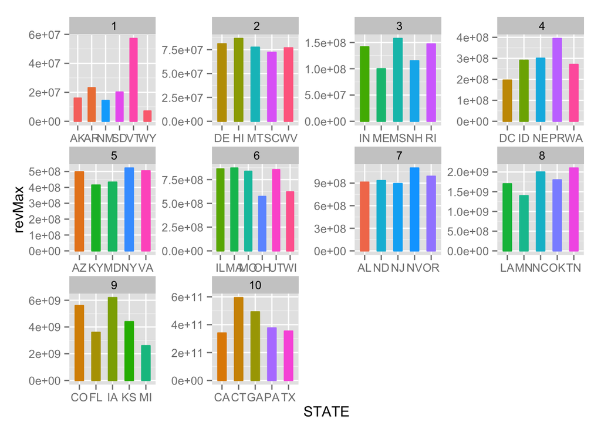

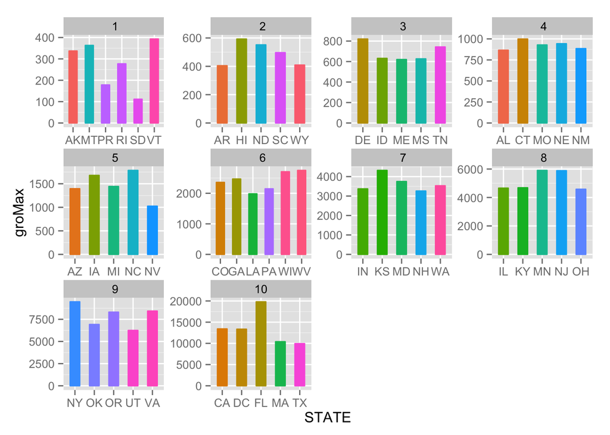

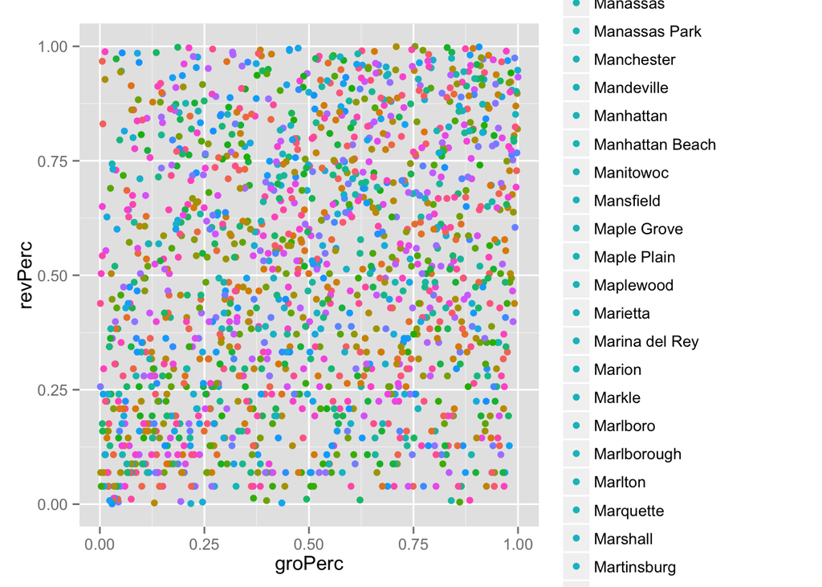